# Employed Status

2025-06-30

```r
library(tidyverse)
library(patchwork)
library(scales)
library(ggplot2)
library(broom)
```

# 1 Dataset Information

Diese Daten enthalten zwei csv-Dateien („Employed“, „Earn“). Die beiden Tabellen zeigen die Anzahl der Arbeitnehmer in der Industrie und die Einkommen der verschiedenen Gruppen von Personen.

Nach dem Laden der Daten entfernen wir einige Fehler oder Doppelungen aus dem Datensatz mithilfe von Methoden (z. B. drop_na(), filter()). Hier ist ein Überblick über den angepassten Datensatz.

```r
cat("**employed.csv:**\n")
```

```
## **employed.csv:**
```

```r
glimpse(employed_cleaned)
```

```
## Rows: 7,392
## Columns: 7
## $ industry         <chr> "Agriculture and related", "Agriculture and related",…
## $ major_occupation <chr> "Management, professional, and related occupations", …
## $ minor_occupation <chr> "Management, business, and financial operations occup…
## $ race_gender      <chr> "TOTAL", "TOTAL", "TOTAL", "TOTAL", "TOTAL", "TOTAL",…
## $ industry_total   <dbl> 2349000, 2349000, 2349000, 2349000, 2349000, 2349000,…
## $ employ_n         <dbl> 961000, 58000, 13000, 94000, 12000, 96000, 931000, 10…
## $ year             <dbl> 2020, 2020, 2020, 2020, 2020, 2020, 2020, 2020, 2020,…
```

```r
cat("**earn.csv:**\n")
```

```
## **earn.csv:**
```

```r
glimpse(earn_filtered)
```

```
## Rows: 924
## Columns: 8
## $ sex                <chr> "Both Sexes", "Both Sexes", "Both Sexes", "Both Sex…
## $ race               <chr> "All Races", "All Races", "All Races", "All Races",…
## $ ethnic_origin      <chr> "All Origins", "All Origins", "All Origins", "All O…
## $ age                <chr> "16 to 19 years", "16 to 19 years", "16 to 19 years…
## $ year               <dbl> 2010, 2010, 2010, 2010, 2011, 2011, 2011, 2011, 201…
## $ quarter            <dbl> 1, 2, 3, 4, 1, 2, 3, 4, 1, 2, 3, 4, 1, 2, 3, 4, 1, …
## $ n_persons          <dbl> 715000, 1119000, 1383000, 933000, 673000, 968000, 1…
## $ median_weekly_earn <dbl> 356, 346, 335, 360, 360, 349, 356, 346, 362, 357, 3…
```

## 1.1 Richtungen von Analysen

1. Analyse von der Beschäftigung
2. Einkommen der verschiedenen Personengruppen

# 2 Analyse von der Beschäftigung

## 2.1 Trends der Beschäftigung in verschiedenen Industrien

Wir haben die sechs interessierenden Industrien aus allen Daten herausgefiltert und die Trends der Beschäftigungszahlen im Zeitverlauf für diese sechs Industrien aufgezeichnet.

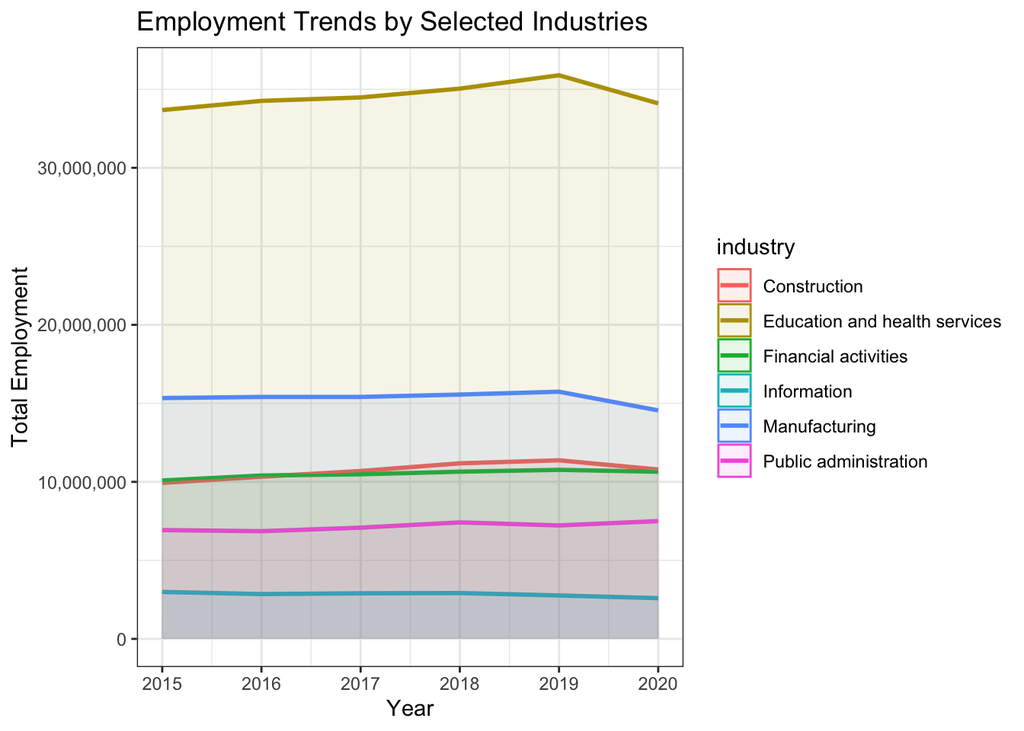

```r
employed_filtered <- employed_cleaned %>%
  filter(industry %in% c(
    "Construction",
    "Manufacturing",
    "Information",
    "Financial activities",  # Finacial
    "Education and health services",
    "Public administration"
  ))

industry_trend <- employed_filtered %>%
  filter(race_gender == "TOTAL") %>%
  group_by(industry, year) %>%
  summarise(total_employment = mean(industry_total, na.rm = TRUE), .groups = "drop") %>%
  arrange(year, industry)

ggplot(industry_trend, aes(x = year, y = total_employment,
                           color = industry, fill = industry)) +
  geom_line(size = 1) +
  geom_area(alpha = 0.1, position = "identity") +
  labs(title = "Employment Trends by Selected Industries",
       x = "Year",
       y = "Total Employment") +
  theme_bw() +
  # theme(legend.position = "bottom") +
  scale_y_continuous(labels = scales::comma)
```

Das Diagramm zeigt, dass der Betrag der Veränderung in jedem Jahr im Vergleich zur Gesamtbeschäftigung gering ist. Daher haben wir die absolute Veränderung von Jahr zu Jahr berechnet. Dies ist in dem folgenden Diagramm dargestellt.

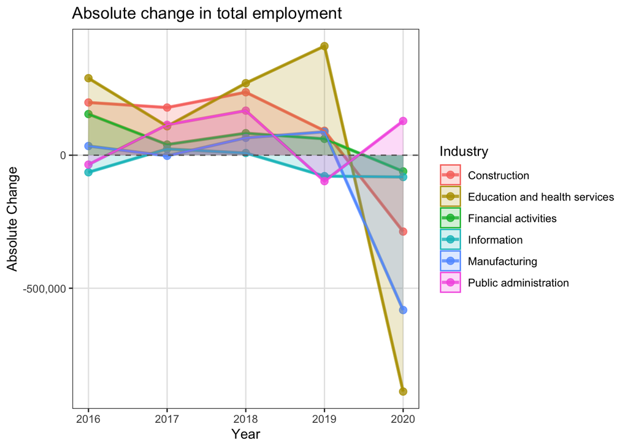

```r
# absolute change
industry_changes <- employed_filtered %>%
  group_by(industry, year) %>%
  summarise(total_employment = mean(industry_total, na.rm = TRUE), .groups = "drop") %>%
  arrange(industry, year) %>%
  group_by(industry) %>%
  mutate(change = total_employment - lag(total_employment)) %>%
  filter(!is.na(change))

ggplot(industry_changes, aes(x = year, y = change, color = industry)) +
  geom_line(size = 1.2, alpha = 0.8) +
  geom_point(size = 2.5, alpha = 0.8) +
  geom_area(aes(fill = industry), alpha = 0.2, position = "identity") +
  geom_hline(yintercept = 0, linetype = "dashed", color = "gray40", size = 0.5) +
  labs(title = "Absolute change in total employment",
       x = "Year",
       y = "Absolute Change",
       color = "Industry",
       fill = "Industry") +
  theme_bw() +
  theme(
    legend.position = "right",
    # legend.box = "horizontal",
    panel.grid.major = element_line(color = "gray90"),
    panel.grid.minor = element_blank()
  ) +
  scale_y_continuous(labels = scales::comma)
```

```r
  # scale_x_continuous(breaks = unique(industry_changes$year)) +
  # guides(color = guide_legend(nrow = 2),
  #        fill = guide_legend(nrow = 2))
```

## 2.2 Beschäftigunganteil von verschiedene Personengruppen

Als Beispiel wird der Beschäftigungsanteil verschiedener Personengruppen in verschiedenen Industrien für das Jahr 2020 analysiert.

Zunächst haben wir den Anteil für verschiedene Gender und verschiedene Races analysiert.

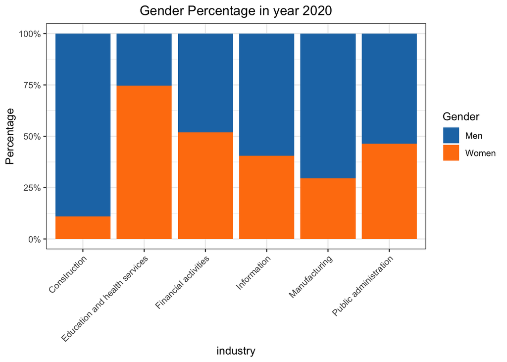

```r
employed_gender_proportion <- employed_filtered %>%
  group_by(industry, year, race_gender) %>%
  summarise(industry_total = mean(industry_total, na.rm = TRUE), .groups = "drop") %>%
  pivot_wider(
    names_from = race_gender,
    values_from = industry_total
  ) %>%
  mutate(
    Men_Percentage = scales::percent(Men/TOTAL, accuracy = 0.1),
    Women_Percentage = scales::percent(Women/TOTAL, accuracy = 0.1),
    White_Percentage = scales::percent(White/TOTAL, accuracy = 0.1),
    Black_Percentage = scales::percent(`Black or African American`/TOTAL, accuracy = 0.1),
    Asian_Percentage = scales::percent(Asian/TOTAL, accuracy = 0.1)
  ) %>%
  select(industry, year, Men_Percentage, Women_Percentage, White_Percentage, Black_Percentage, Asian_Percentage) %>%
  arrange(industry, year)


data_2020 <- employed_gender_proportion %>%
  filter(year == 2020) %>%
  mutate(
    Men = as.numeric(gsub("%", "", Men_Percentage))/100,
    Women = as.numeric(gsub("%", "", Women_Percentage))/100,
    White = as.numeric(gsub("%", "", White_Percentage))/100,
    `Black or African American` = as.numeric(gsub("%", "", Black_Percentage))/100,
    Asian = as.numeric(gsub("%", "", Asian_Percentage))/100
  ) %>%
  select(industry, Men, Women, White, `Black or African American`, Asian) %>%
  pivot_longer(
    cols = -industry,
    names_to = "category",
    values_to = "percentage"
  )

data_2020 %>%
  filter(category %in% c("Men", "Women")) %>%
  ggplot(aes(x = industry, y = percentage, fill = category)) +
  geom_col(position = "stack") +
  scale_y_continuous(labels = percent_format(), limits = c(0, 1)) +
  scale_fill_manual(values = c("Men" = "#1f77b4", "Women" = "#ff7f0e")) +
  labs(title = "Gender Percentage in year 2020",
       x = "industry",
       y = "Percentage",
       fill = "Gender") +
  theme_bw() +
  theme(axis.text.x = element_text(angle = 45, hjust = 1),
        plot.title = element_text(hjust = 0.5))
```

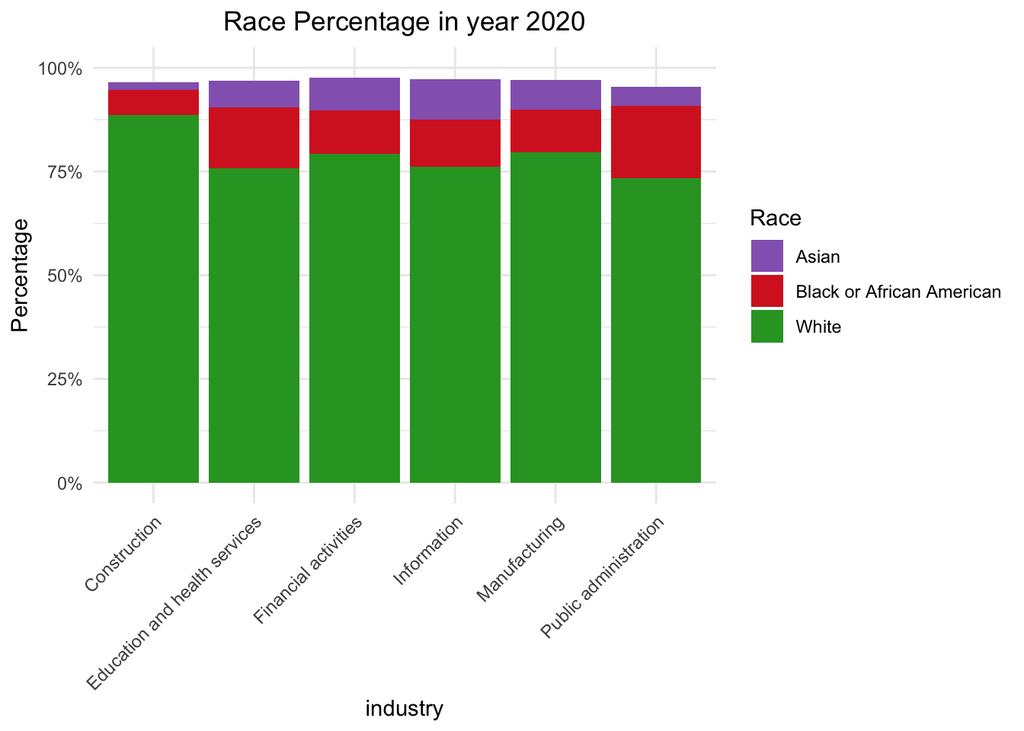

```r
data_2020 %>%
  filter(category %in% c("White", "Black or African American", "Asian")) %>%
  ggplot(aes(x = industry, y = percentage, fill = category)) +
  geom_col(position = "stack") +
  scale_y_continuous(labels = percent_format(), limits = c(0, 1)) +
  scale_fill_manual(values = c("White" = "#2ca02c", "Black or African American" = "#d62728", "Asian" = "#9467bd")) +
  labs(title = "Race Percentage in year 2020",
       x = "industry",
       y = "Percentage",
       fill = "Race") +
  theme_minimal() +
  theme(axis.text.x = element_text(angle = 45, hjust = 1),
        plot.title = element_text(hjust = 0.5))
```

Analyse: Diagramm 1: Der Anteil der Männer im Construction ist wesentlich höher als der der Frauen. Im Education ist es umgekehrt. Diagramm 2: In allen Industrien in USA sind die White in der Mehrzahl, besonders in der Industrie Construction.

# 3 Einkommen der verschiedenen Personengruppen

## 3.1 Analyse nach Race

So hat sich der durchschnittliche Wochenverdienst im Laufe der Jahre nach Race verändert

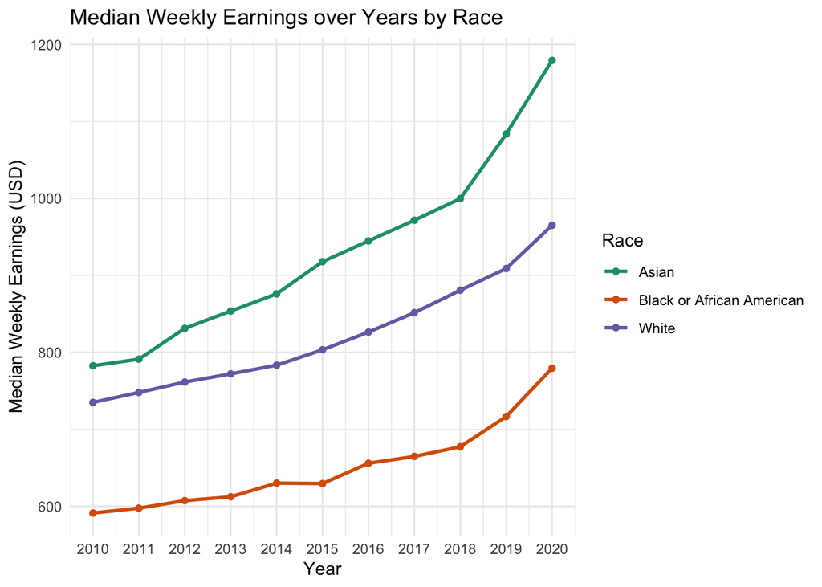

```r
# filter and get three races
earn_filtered_race <- earn %>%
  filter(race %in% c("White", "Black or African American", "Asian")) %>%
  filter(!is.na(race), !is.na(year), !is.na(median_weekly_earn))

# calculate median salary
earn_race_year <- earn_filtered_race %>%
  group_by(race, year) %>%
  summarise(median_earn = mean(median_weekly_earn, na.rm = TRUE)) %>%
  ungroup() %>%
  mutate(year_int = floor(year))


ggplot(earn_race_year, aes(x = year_int, y = median_earn, color = race, group = race)) +
  geom_line(size = 1) +
  geom_point() +
  theme_minimal() +
  labs(
    title = "Median Weekly Earnings over Years by Race",
    x = "Year",
    y = "Median Weekly Earnings (USD)",
    color = "Race"
  ) +
  scale_x_continuous(breaks = unique(earn_race_year$year_int)) +
  scale_color_brewer(palette = "Dark2")
```

Analyse: Aus dem Diagramm ist ersichtlich, dass das Lohnniveau aller ethnischen Gruppen steigt, wobei das Durchschnittseinkommen der asiatischen Bevölkerung durchgehend am höchsten ist.

## 3.2 Analyse nach Geschlecht

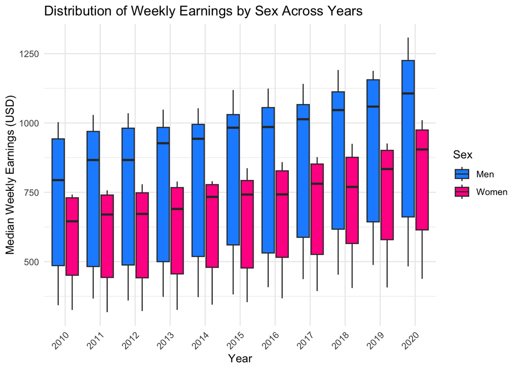

```r
# filter with gender
earn_box <- earn_filtered %>%
  filter(sex %in% c("Men", "Women")) %>%
  filter(!is.na(median_weekly_earn), !is.na(year))


earn_box <- earn_box %>%
  mutate(year_int = floor(year))


ggplot(earn_box, aes(x = factor(year_int), y = median_weekly_earn, fill = sex)) +
  geom_boxplot(outlier.alpha = 0.3, width = 0.7, position = position_dodge(0.8)) +
  scale_fill_manual(values = c("Women" = "deeppink", "Men" = "dodgerblue")) +
  labs(
    title = "Distribution of Weekly Earnings by Sex Across Years",
    x = "Year",
    y = "Median Weekly Earnings (USD)",
    fill = "Sex"
  ) +
  theme_minimal() +
  theme(axis.text.x = element_text(angle = 45, hjust = 1))
```

Analyse: Wie aus dem Diagramm zu erkennen ist, sind die Durchschnittseinkommen sowohl von Männern als auch von Frauen im Laufe der Jahre gestiegen, aber das durchschnittliche Wocheneinkommen der Männer ist im Allgemeinen höher als das der Frauen.Bei den Männern ist die Einkommensspanne zwischen dem oberen und unteren Ende relativ groß.

## 3.3 Analyse nach Alter

Hier ist der durchschnittliche Wochenverdienst nach Altersgruppen im Jahr 2016 Die folgende Tabelle zeigt beispielsweise das Durchschnittseinkommen für jede Altersgruppe im Jahr 2016

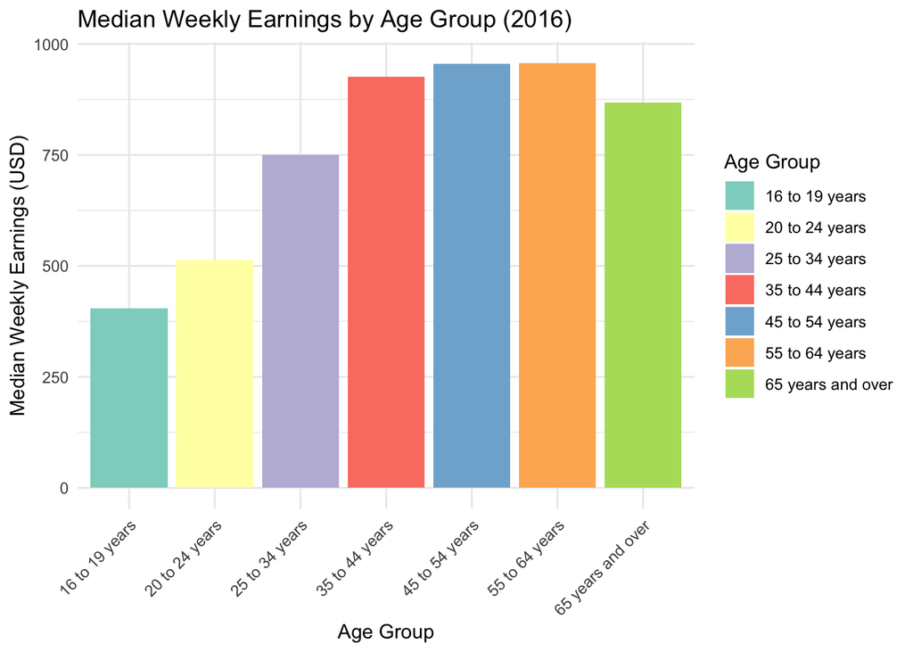

```r
# 2016
earn_2016 <- earn_filtered %>%
  filter(year == 2016)


earn_2016_grouped <- earn_2016 %>%
  group_by(age) %>%
  summarise(median_earn = mean(median_weekly_earn, na.rm = TRUE)) %>%
  ungroup()


age_levels <- c("16 to 19 years", "20 to 24 years", "25 to 34 years",
                "25 years and over", "35 to 44 years", "45 to 54 years",
                "55 to 64 years", "55 years and over", "65 years and over")


earn_2016_grouped <- earn_2016_grouped %>%
  filter(age %in% age_levels) %>%
  mutate(age = factor(age, levels = age_levels))


ggplot(earn_2016_grouped, aes(x = age, y = median_earn, fill = age)) +
  geom_col() +
  theme_minimal() +
  labs(
    title = "Median Weekly Earnings by Age Group (2016)",
    x = "Age Group",
    y = "Median Weekly Earnings (USD)"
  ) +
  theme(axis.text.x = element_text(angle = 45, hjust = 1)) +
  scale_fill_brewer(palette = "Set3", name = "Age Group")
```

Analyse: Es ist erkennbar, dass mit zunehmendem Alter das Lohnniveau schrittweise steigt, jedoch sinkt es bei den über 65-Jährigen.

Diese Grafik zeigt die Entwicklung des Durchschnittseinkommens nach Altersgruppen

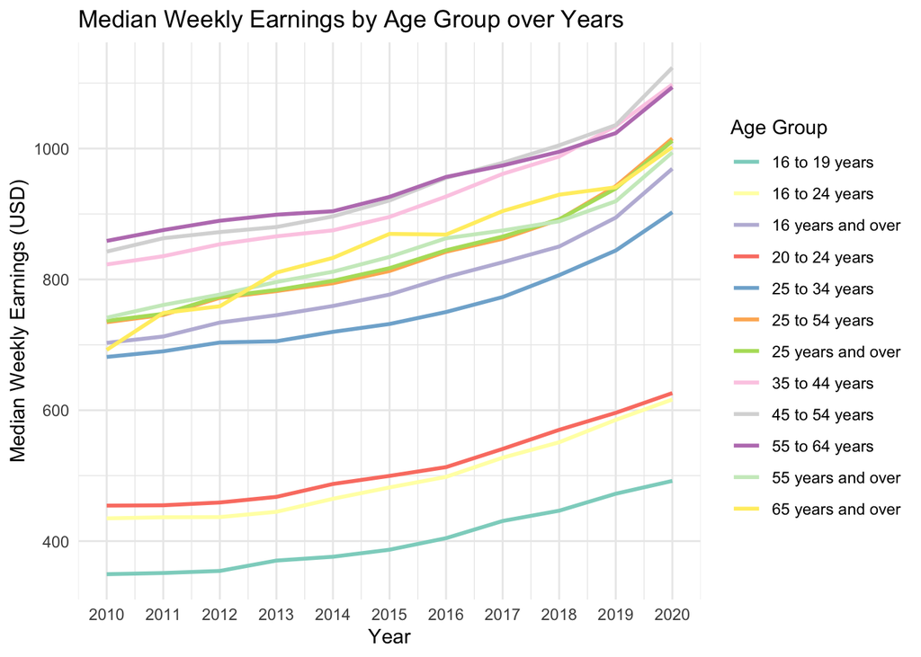

```r
earn_by_age_year <- earn %>%
  group_by(age, year) %>%
  summarise(median_earn = mean(median_weekly_earn, na.rm = TRUE)) %>%
  ungroup() %>%
  filter(!is.na(age))


existing_ages <- sort(unique(earn_by_age_year$age))
earn_by_age_year$age <- factor(earn_by_age_year$age, levels = existing_ages)


earn_by_age_year <- earn_by_age_year %>%
  mutate(year_int = floor(year))

ggplot(earn_by_age_year, aes(x = year_int, y = median_earn, color = age, group = age)) +
  geom_line(size = 1) +
  theme_minimal() +
  labs(
    title = "Median Weekly Earnings by Age Group over Years",
    x = "Year",
    y = "Median Weekly Earnings (USD)",
    color = "Age Group"
  ) +
  scale_x_continuous(breaks = unique(earn_by_age_year$year_int)) +  # 保证x轴每年都有刻度
  scale_color_brewer(palette = "Set3")
```

Wir haben drei Altersgruppen ausgewählt und t-Tests durchgeführt.

```r
earn_subset <- earn_filtered %>%
  filter(age %in% c("20 to 24 years", "35 to 44 years", "65 years and over")) %>%
  filter(!is.na(median_weekly_earn))


age_pairs <- list(
  c("20 to 24 years", "35 to 44 years"),
  c("20 to 24 years", "65 years and over"),
  c("35 to 44 years", "65 years and over")
)


t_results <- purrr::map_df(age_pairs, function(pair) {
  group1 <- earn_subset %>% filter(age == pair[1]) %>% pull(median_weekly_earn)
  group2 <- earn_subset %>% filter(age == pair[2]) %>% pull(median_weekly_earn)

  test <- t.test(group1, group2)

  tibble(
    age_group_1 = pair[1],
    age_group_2 = pair[2],
    mean1 = mean(group1),
    mean2 = mean(group2),
    mean_diff = mean(group1) - mean(group2),
    p_value = test$p.value,
    significance = case_when(
      test$p.value < 0.001 ~ "***",
      test$p.value < 0.01  ~ "**",
      test$p.value < 0.05  ~ "*",
      TRUE                 ~ ""
    )
  )
})


print(t_results)
```

```
## # A tibble: 3 × 7
##   age_group_1    age_group_2       mean1 mean2 mean_diff  p_value significance
##   <chr>          <chr>             <dbl> <dbl>     <dbl>    <dbl> <chr>
## 1 20 to 24 years 35 to 44 years     515.  923.    -408.  9.71e-87 ***
## 2 20 to 24 years 65 years and over  515.  851.    -335.  3.56e-64 ***
## 3 35 to 44 years 65 years and over  923.  851.      72.6 4.82e- 6 ***
```

# 4 Fazit

Die Ergebnisse der T-Tests bestätigen, dass die Einkommensunterschiede zwischen jungen und älteren Altersgruppen signifikant sind. Besonders deutlich ist der Unterschied zwischen den 20- bis 24-Jährigen und den älteren Gruppen. Ab etwa 35 Jahren verlangsamt sich das Lohnwachstum jedoch spürbar.